# PPL Project (titanic) Part 1

Mohit Zanwar - 111903145

Rohaan Advani - 111903151

Varun Taneja - 111903158

Yash Dhake - 111903160

## Complete EDA for Titanic Dataset. Try and draw as many insights about the passengers in the TITANIC.

```python
import numpy as np
import pandas as pd
import matplotlib.pyplot as plt
%matplotlib inline
import seaborn as sns
```

```python
eda = pd.read_csv('TITANIC.csv.txt')
```

```python
eda.head()
```

|  | PassengerId | Survived | Pclass | Name | Sex | Age | SibSp | Parch | Ticket | Fare | Cabin | Embarked |
| --- | --- | --- | --- | --- | --- | --- | --- | --- | --- | --- | --- | --- |
| 0 | 1 | 0 | 3 | Braund, Mr. Owen Harris | male | 22.0 | 1 | 0 | A/5 21171 | 7.2500 | NaN | S |
| 1 | 2 | 1 | 1 | Cumings, Mrs. John Bradley (Florence Briggs Th... | female | 38.0 | 1 | 0 | PC 17599 | 71.2833 | C85 | C |
| 2 | 3 | 1 | 3 | Heikkinen, Miss. Laina | female | 26.0 | 0 | 0 | STON/O2. 3101282 | 7.9250 | NaN | S |
| 3 | 4 | 1 | 1 | Futrelle, Mrs. Jacques Heath (Lily May Peel) | female | 35.0 | 1 | 0 | 113803 | 53.1000 | C123 | S |
| 4 | 5 | 0 | 3 | Allen, Mr. William Henry | male | 35.0 | 0 | 0 | 373450 | 8.0500 | NaN | S |

```python
eda.tail()
```

|  | PassengerId | Survived | Pclass | Name | Sex | Age | SibSp | Parch | Ticket | Fare | Cabin | Embarked |
| --- | --- | --- | --- | --- | --- | --- | --- | --- | --- | --- | --- | --- |
| 886 | 887 | 0 | 2 | Montvila, Rev. Juozas | male | 27.0 | 0 | 0 | 211536 | 13.00 | NaN | S |
| 887 | 888 | 1 | 1 | Graham, Miss. Margaret Edith | female | 19.0 | 0 | 0 | 112053 | 30.00 | B42 | S |
| 888 | 889 | 0 | 3 | Johnston, Miss. Catherine Helen "Carrie" | female | NaN | 1 | 2 | W./C. 6607 | 23.45 | NaN | S |
| 889 | 890 | 1 | 1 | Behr, Mr. Karl Howell | male | 26.0 | 0 | 0 | 111369 | 30.00 | C148 | C |
| 890 | 891 | 0 | 3 | Dooley, Mr. Patrick | male | 32.0 | 0 | 0 | 370376 | 7.75 | NaN | Q |

```python
eda.describe()
```

|  | PassengerId | Survived | Pclass | Age | SibSp | Parch | Fare |
| --- | --- | --- | --- | --- | --- | --- | --- |
| count | 891.000000 | 891.000000 | 891.000000 | 714.000000 | 891.000000 | 891.000000 | 891.000000 |
| mean | 446.000000 | 0.383838 | 2.308642 | 29.699118 | 0.523008 | 0.381594 | 32.204208 |
| std | 257.353842 | 0.486592 | 0.836071 | 14.526497 | 1.102743 | 0.806057 | 49.693429 |
| min | 1.000000 | 0.000000 | 1.000000 | 0.420000 | 0.000000 | 0.000000 | 0.000000 |
| 25% | 223.500000 | 0.000000 | 2.000000 | 20.125000 | 0.000000 | 0.000000 | 7.910400 |
| 50% | 446.000000 | 0.000000 | 3.000000 | 28.000000 | 0.000000 | 0.000000 | 14.454200 |
| 75% | 668.500000 | 1.000000 | 3.000000 | 38.000000 | 1.000000 | 0.000000 | 31.000000 |
| max | 891.000000 | 1.000000 | 3.000000 | 80.000000 | 8.000000 | 6.000000 | 512.329200 |

```python
eda.info()
```

```
<class 'pandas.core.frame.DataFrame'>
RangeIndex: 891 entries, 0 to 890
Data columns (total 12 columns):
 #   Column       Non-Null Count  Dtype
---  ------       --------------  -----
 0   PassengerId  891 non-null    int64
 1   Survived     891 non-null    int64
 2   Pclass       891 non-null    int64
 3   Name         891 non-null    object
 4   Sex          891 non-null    object
 5   Age          714 non-null    float64
 6   SibSp        891 non-null    int64
 7   Parch        891 non-null    int64
 8   Ticket       891 non-null    object
 9   Fare         891 non-null    float64
 10  Cabin        204 non-null    object
 11  Embarked     889 non-null    object
dtypes: float64(2), int64(5), object(5)
memory usage: 83.7+ KB
```

### Step 1 : Variable Identification

Dependent variable: Survived

Independent variables: PassengerId, Pclass, Name, Sex, Age, SibSp, Parch, Ticket, Fare, Cabin, Embarked.

```python
eda.info()
```

```
<class 'pandas.core.frame.DataFrame'>
RangeIndex: 891 entries, 0 to 890
Data columns (total 12 columns):
 #   Column       Non-Null Count  Dtype
---  ------       --------------  -----
 0   PassengerId  891 non-null    int64
 1   Survived     891 non-null    int64
 2   Pclass       891 non-null    int64
 3   Name         891 non-null    object
 4   Sex          891 non-null    object
 5   Age          714 non-null    float64
 6   SibSp        891 non-null    int64
 7   Parch        891 non-null    int64
 8   Ticket       891 non-null    object
 9   Fare         891 non-null    float64
 10  Cabin        204 non-null    object
 11  Embarked     889 non-null    object
dtypes: float64(2), int64(5), object(5)
memory usage: 83.7+ KB
```

### Data Types:

```
String -
    Name
    Sex
    Ticket
    Cabin
    Embarked

Numeric -
    PassengerId
    Suevived
    Pclass
    Age
    SibSp
    Parch
    Fare
```

### Variable Category:

Variable Category:

Categorical -

```
 1.Sex
 2.Survived
 3.Embarked
 4.Pclass
```

Continuous -

```
 1.Age
 2.Fare
```

Discreet -

```
 1.PassengerId
 2.SibSp
 3.Parch
```

Descriptive -

```
 1.Name
 2.Ticket
 3.Cabin
```

### Description of the data

1. PassengerId: an id that is given to each traveler
2. Pclass: Passenger class, It has three possible values: 1,2,3 (first, second and third class)
3. The Name of the passenger
4. The Sex of the passenger
5. The Age of the passenger
6. SibSp: number of siblings and spouses traveling with the passenger
7. Parch: number of parents and children traveling with the passenger
8. The ticket number of the passenger
9. The ticket fare paid by the passenger
10. The cabin number of the passenger
11. The embarkation, This describes three possible areas of the Titanic from which the people embark. Three possible values S, C, Q

## Step 2: Univariate Analysis

### For categorical variables -

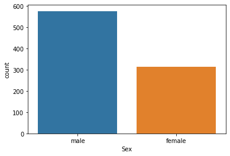

```python
sns.countplot(x='Sex', data=eda)
```

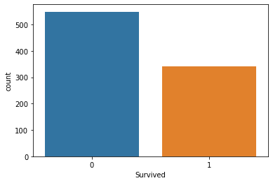

```python
sns.countplot(x='Survived', data=eda)
```

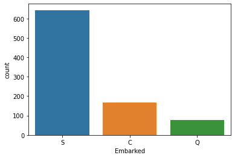

```python
sns.countplot(x='Embarked', data=eda)
```

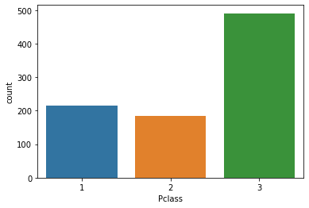

```python
sns.countplot(x='Pclass', data=eda)
```

### For continuous data

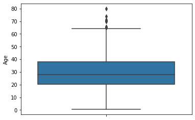

```python
sns.boxplot(y = 'Age', data = eda)
```

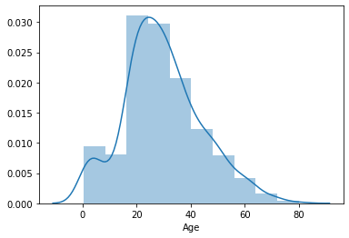

```python
sns.distplot(eda['Age'], bins = 10)
```

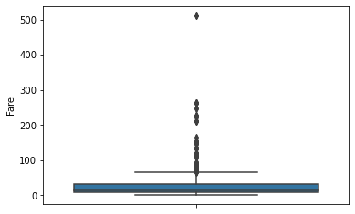

```python
sns.boxplot(y = 'Fare', data = eda)
```

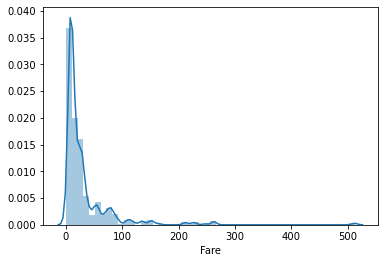

```python
sns.distplot(eda['Fare'], bins = 50)
```

### For discreet data

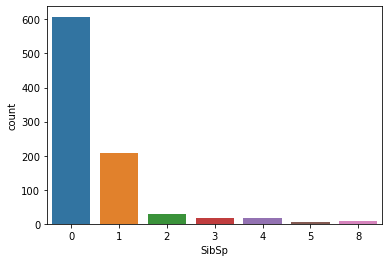

```python
sns.countplot(x='SibSp', data=eda)
```

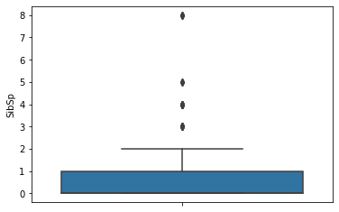

```python
sns.boxplot(y = 'SibSp', data = eda)
```

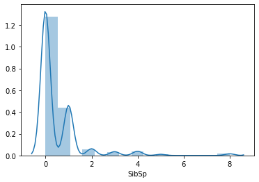

```python
sns.distplot(eda['SibSp'], bins = 15)
```

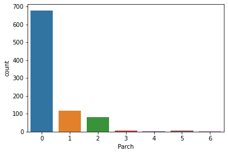

```python
sns.countplot(x='Parch', data=eda)
```

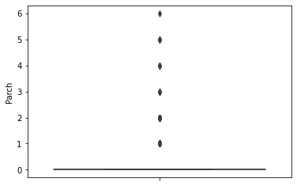

```python
sns.boxplot(y = 'Parch', data = eda)
```

## Step 3 - Bivariate Analysis

### For Coninuous & Continuous

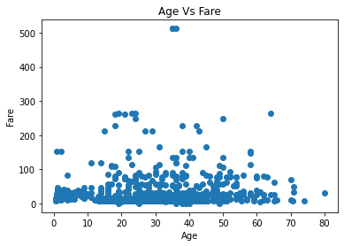

```python
plt.scatter(eda['Age'], eda['Fare'])
plt.title('Age Vs Fare')
plt.xlabel('Age')
plt.ylabel('Fare')
```

### Discreet vs Discreet

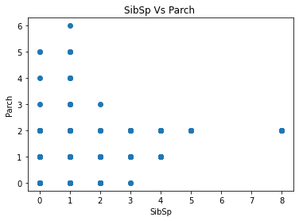

```python
plt.scatter(eda['SibSp'], eda['Parch'])
plt.title('SibSp Vs Parch ')
plt.xlabel('SibSp')
plt.ylabel('Parch')
```

### For categorical vs categorical

```python
counts = eda.groupby(['Sex', 'Embarked'], axis= 0)
counts.size()
```

```
Sex     Embarked
female  C            73
        Q            36
        S           203
male    C            95
        Q            41
        S           441
dtype: int64
```

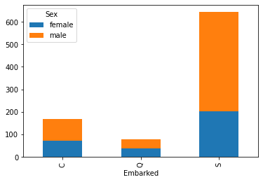

```python
pd.crosstab(eda['Embarked'],eda['Sex']).plot(kind='bar',stacked=True)
```

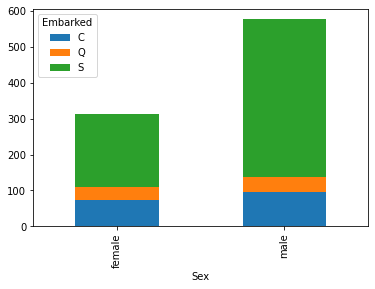

```python
pd.crosstab(eda['Sex'],eda['Embarked']).plot(kind='bar',stacked=True)
```

```python
counts = eda.groupby(['Sex', 'Survived'], axis= 0)
counts.size()
```

```
Sex     Survived
female  0            81
        1           233
male    0           468
        1           109
dtype: int64
```

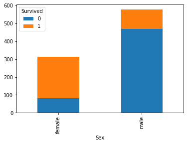

```python
pd.crosstab(eda['Sex'],eda['Survived']).plot(kind='bar',stacked=True)
```

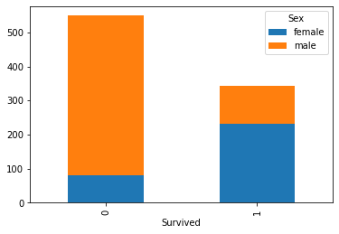

```python
pd.crosstab(eda['Survived'],eda['Sex']).plot(kind='bar',stacked=True)
```

```python
counts = eda.groupby(['Sex', 'Pclass'], axis= 0)
counts.size()
```

```
Sex     Pclass
female  1          94
        2          76
        3         144
male    1         122
        2         108
        3         347
dtype: int64
```

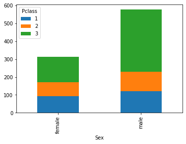

```python
pd.crosstab(eda['Sex'],eda['Pclass']).plot(kind='bar',stacked=True)
```

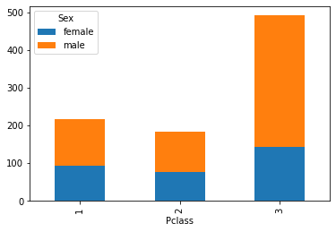

```python
pd.crosstab(eda['Pclass'],eda['Sex']).plot(kind='bar',stacked=True)
```

```python
counts = eda.groupby(['Embarked', 'Survived'], axis= 0)
counts.size()
```

```
Embarked  Survived
C         0            75
          1            93
Q         0            47
          1            30
S         0           427
          1           217
dtype: int64
```

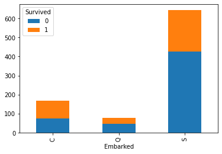

```python
pd.crosstab(eda['Embarked'],eda['Survived']).plot(kind='bar',stacked=True)
```

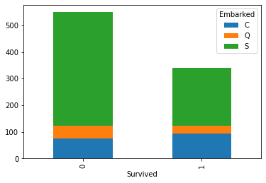

```python
pd.crosstab(eda['Survived'],eda['Embarked']).plot(kind='bar',stacked=True)
```

```python
counts = eda.groupby(['Embarked', 'Pclass'], axis= 0)
counts.size()
```

```
Embarked  Pclass
C         1          85
          2          17
          3          66
Q         1           2
          2           3
          3          72
S         1         127
          2         164
          3         353
dtype: int64
```

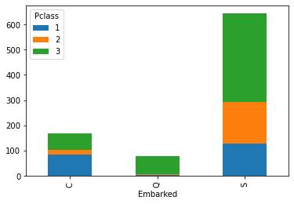

```python
pd.crosstab(eda['Embarked'],eda['Pclass']).plot(kind='bar',stacked=True)
```

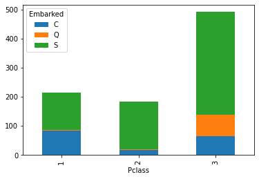

```python
pd.crosstab(eda['Pclass'],eda['Embarked']).plot(kind='bar',stacked=True)
```

```python
counts = eda.groupby(['Pclass', 'Survived'], axis= 0)
counts.size()
```

```
Pclass  Survived
1       0            80
        1           136
2       0            97
        1            87
3       0           372
        1           119
dtype: int64
```

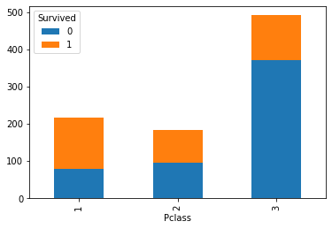

```python
pd.crosstab(eda['Pclass'],eda['Survived']).plot(kind='bar',stacked=True)
```

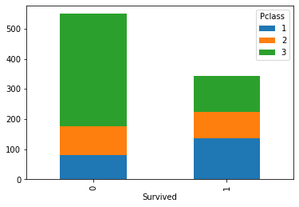

```python
pd.crosstab(eda['Survived'],eda['Pclass']).plot(kind='bar',stacked=True)
```

### For all types

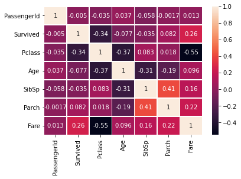

```python
sns.heatmap(eda.corr(), annot=True, linewidth=0.5)
```

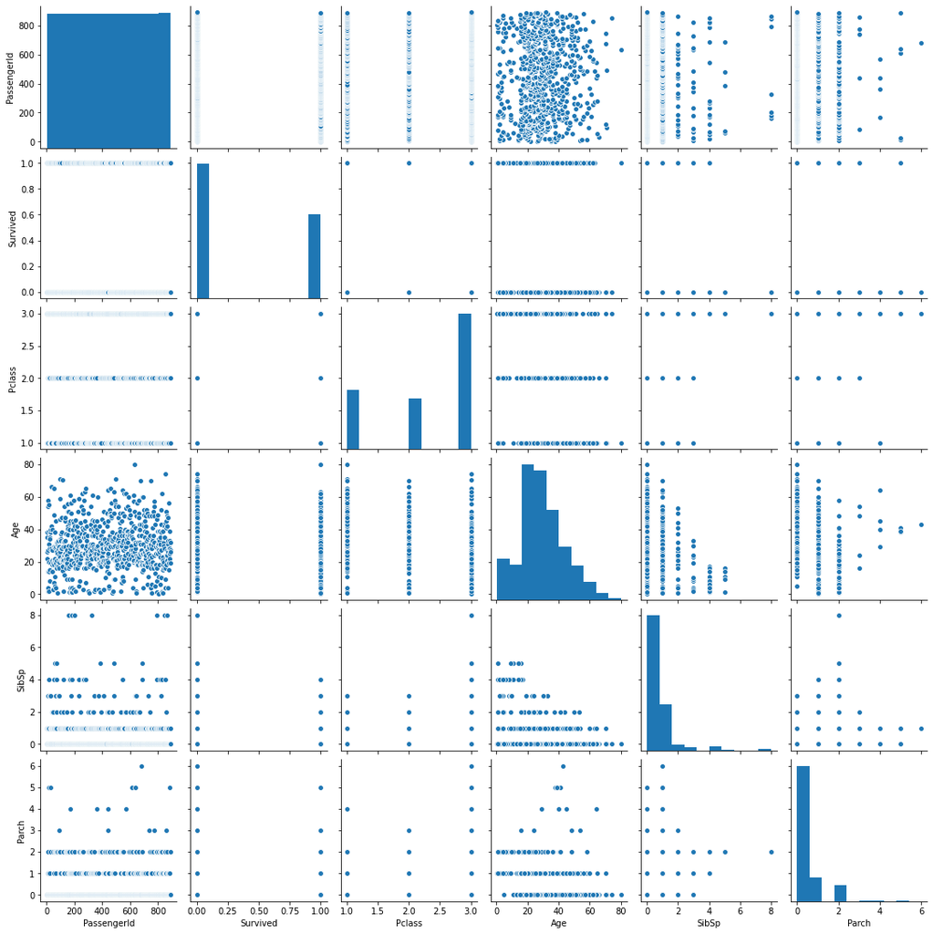

```python
eda_cont = eda.iloc[:,:-3]
eda_cont
sns.pairplot(eda_cont)
```

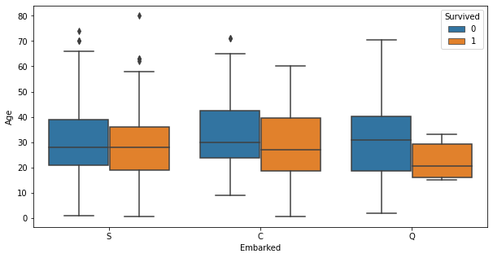

```python
plt.figure(figsize=(10,5))
sns.boxplot(x='Embarked', y='Age', data=eda, hue='Survived')
```

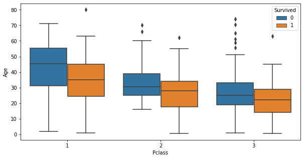

```python
plt.figure(figsize=(10,5))
sns.boxplot(x='Pclass', y='Age', data=eda, hue='Survived')
```

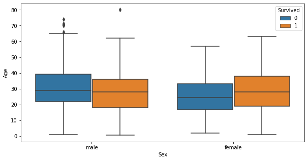

```python
plt.figure(figsize=(10,5))
sns.boxplot(x='Sex', y='Age', data=eda, hue='Survived')
```

## Step 4: Treatment of missing values

```python
eda.isnull()
```

|  | PassengerId | Survived | Pclass | Name | Sex | Age | SibSp | Parch | Ticket | Fare | Cabin | Embarked |
| --- | --- | --- | --- | --- | --- | --- | --- | --- | --- | --- | --- | --- |
| 0 | False | False | False | False | False | False | False | False | False | False | True | False |
| 1 | False | False | False | False | False | False | False | False | False | False | False | False |
| 2 | False | False | False | False | False | False | False | False | False | False | True | False |
| 3 | False | False | False | False | False | False | False | False | False | False | False | False |
| 4 | False | False | False | False | False | False | False | False | False | False | True | False |
| ... | ... | ... | ... | ... | ... | ... | ... | ... | ... | ... | ... | ... |
| 886 | False | False | False | False | False | False | False | False | False | False | True | False |
| 887 | False | False | False | False | False | False | False | False | False | False | False | False |
| 888 | False | False | False | False | False | True | False | False | False | False | True | False |
| 889 | False | False | False | False | False | False | False | False | False | False | False | False |
| 890 | False | False | False | False | False | False | False | False | False | False | True | False |

891 rows × 12 columns

```python
eda.isnull().values.any()
```

```
True
```

```python
eda.info()
```

```
<class 'pandas.core.frame.DataFrame'>
RangeIndex: 891 entries, 0 to 890
Data columns (total 12 columns):
 #   Column       Non-Null Count  Dtype
---  ------       --------------  -----
 0   PassengerId  891 non-null    int64
 1   Survived     891 non-null    int64
 2   Pclass       891 non-null    int64
 3   Name         891 non-null    object
 4   Sex          891 non-null    object
 5   Age          714 non-null    float64
 6   SibSp        891 non-null    int64
 7   Parch        891 non-null    int64
 8   Ticket       891 non-null    object
 9   Fare         891 non-null    float64
 10  Cabin        204 non-null    object
 11  Embarked     889 non-null    object
dtypes: float64(2), int64(5), object(5)
memory usage: 83.7+ KB
```

```python
eda.isnull().sum()
```

```
PassengerId      0
Survived         0
Pclass           0
Name             0
Sex              0
Age            177
SibSp            0
Parch            0
Ticket           0
Fare             0
Cabin          687
Embarked         2
dtype: int64
```

As we know missing Data will not make any impact on the result if its percentage is less 1%, if missing data’s range within the range of 1-5% then it is somehow manageable; however in case of 5-15% complex techniques are used for handling the problems of missing data but if it exceeds from 15% then it will surely hinder the result achieved after applying data mining techniques.

1) Percentage of null values in Age column = 19.86%

2) Percentage of null values in Cabin column = 77.1%

As cabin has such a high % of null values and will definately cause extreme problems in our model hence its dropped.

3) As Percentage of null values in Embarked column = 0.22%, we can ignore those as they wont affect calculations in our model.

### Deleting observation / variables

```python
eda.drop('Cabin', axis = 1, inplace =True )
```

```python
eda.head()
#cabin has been dropped successfully
```

|  | PassengerId | Survived | Pclass | Name | Sex | Age | SibSp | Parch | Ticket | Fare | Embarked |
| --- | --- | --- | --- | --- | --- | --- | --- | --- | --- | --- | --- |
| 0 | 1 | 0 | 3 | Braund, Mr. Owen Harris | male | 22.0 | 1 | 0 | A/5 21171 | 7.2500 | S |
| 1 | 2 | 1 | 1 | Cumings, Mrs. John Bradley (Florence Briggs Th... | female | 38.0 | 1 | 0 | PC 17599 | 71.2833 | C |
| 2 | 3 | 1 | 3 | Heikkinen, Miss. Laina | female | 26.0 | 0 | 0 | STON/O2. 3101282 | 7.9250 | S |
| 3 | 4 | 1 | 1 | Futrelle, Mrs. Jacques Heath (Lily May Peel) | female | 35.0 | 1 | 0 | 113803 | 53.1000 | S |
| 4 | 5 | 0 | 3 | Allen, Mr. William Henry | male | 35.0 | 0 | 0 | 373450 | 8.0500 | S |

### Impulation ( Single)

1) If the variable is numeric then replace the missing values with either mean, median or mode.

2) If the variable is otherwise generally normally distributed (and in particular does not have any skewness), we would choose mean.

3) If the data skewed, median imputation is suggested.

4) If the variable is categorical then we could replace the missing values with the most frequent occurring value in that variable, i.e the mode.

5) We use the fillna function of pandas to replace na values with the value of our interest and inplace=True command makes the permanently changes the value in that dataframe

```
array([[<matplotlib.axes._subplots.AxesSubplot object at 0x00000213EAE18EB0>]],
      dtype=object)
```

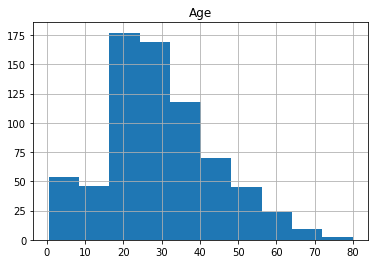

```python
eda.hist(column = ['Age'])
```

```python
eda['Age'] = eda['Age'].fillna(value = eda['Age'].median())
#null values of age have been filled
```

```python
eda.info()
```

```
<class 'pandas.core.frame.DataFrame'>
RangeIndex: 891 entries, 0 to 890
Data columns (total 11 columns):
 #   Column       Non-Null Count  Dtype
---  ------       --------------  -----
 0   PassengerId  891 non-null    int64
 1   Survived     891 non-null    int64
 2   Pclass       891 non-null    int64
 3   Name         891 non-null    object
 4   Sex          891 non-null    object
 5   Age          891 non-null    float64
 6   SibSp        891 non-null    int64
 7   Parch        891 non-null    int64
 8   Ticket       891 non-null    object
 9   Fare         891 non-null    float64
 10  Embarked     889 non-null    object
dtypes: float64(2), int64(5), object(4)
memory usage: 76.7+ KB
```

```python
eda.isnull().sum()
```

```
PassengerId    0
Survived       0
Pclass         0
Name           0
Sex            0
Age            0
SibSp          0
Parch          0
Ticket         0
Fare           0
Embarked       2
dtype: int64
```

The null values have been filled successfully and the two missing values of embarked can be considered insignificant.

## Step 5 : Outlier Detection

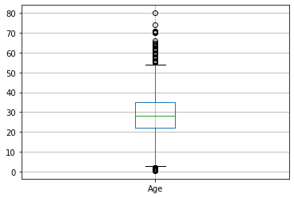

```python
eda.boxplot(column = ['Age'])
```

```python
eda['Age'].describe()
```

```
count    891.000000
mean      29.361582
std       13.019697
min        0.420000
25%       22.000000
50%       28.000000
75%       35.000000
max       80.000000
Name: Age, dtype: float64
```

```python
IQR_age = eda['Age'].quantile(0.75)-eda['Age'].quantile(0.25)
print(IQR_age)
```

```
13.0
```

```python
Upper_OutlierLimit_age = eda['Age'].quantile(0.75) + 1.5*IQR_age
Lower_OutlierLimit_age = eda['Age'].quantile(0.25) - 1.5*IQR_age
print(Upper_OutlierLimit_age)
print(Lower_OutlierLimit_age)
```

```
54.5
2.5
```

```python
OutlierValues_age = eda[(eda['Age']>=Upper_OutlierLimit_age) | (eda['Age']<=Lower_OutlierLimit_age)]
```

```python
OutlierValues_age.describe()
```

|  | PassengerId | Survived | Pclass | Age | SibSp | Parch | Fare |
| --- | --- | --- | --- | --- | --- | --- | --- |
| count | 66.000000 | 66.000000 | 66.000000 | 66.000000 | 66.000000 | 66.000000 | 66.000000 |
| mean | 428.878788 | 0.424242 | 1.893939 | 39.941970 | 0.712121 | 0.681818 | 41.211615 |
| std | 262.023928 | 0.498015 | 0.879314 | 29.752738 | 1.237431 | 0.844149 | 45.675153 |
| min | 8.000000 | 0.000000 | 1.000000 | 0.420000 | 0.000000 | 0.000000 | 6.237500 |
| 25% | 187.000000 | 0.000000 | 1.000000 | 2.000000 | 0.000000 | 0.000000 | 13.750000 |
| 50% | 462.500000 | 0.000000 | 2.000000 | 57.500000 | 0.000000 | 0.000000 | 26.550000 |
| 75% | 644.500000 | 1.000000 | 3.000000 | 62.000000 | 1.000000 | 1.000000 | 39.515625 |
| max | 880.000000 | 1.000000 | 3.000000 | 80.000000 | 5.000000 | 4.000000 | 263.000000 |

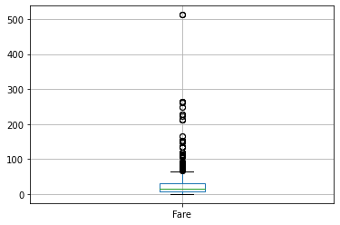

```python
eda.boxplot(column = ['Fare'])
```

```python
eda['Fare'].describe()
```

```
count    891.000000
mean      32.204208
std       49.693429
min        0.000000
25%        7.910400
50%       14.454200
75%       31.000000
max      512.329200
Name: Fare, dtype: float64
```

```python
IQR_fare= eda['Fare'].quantile(0.75)-eda['Fare'].quantile(0.25)
print(IQR_fare)
```

```
23.0896
```

```python
Upper_OutlierLimit_fare = eda['Fare'].quantile(0.75) + 1.5*IQR_fare
Lower_OutlierLimit_fare = eda['Fare'].quantile(0.25) - 1.5*IQR_fare
print(Upper_OutlierLimit_fare)
print(Lower_OutlierLimit_fare)
```

```
65.6344
-26.724
```

```python
OutlierValues_fare = eda[(eda['Fare']>=Upper_OutlierLimit_fare) | (eda['Fare']<=Lower_OutlierLimit_fare)]
```

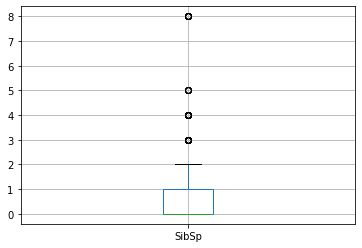

```python
eda.boxplot(column = ['SibSp'])
```

```python
IQR_sibsp= eda['SibSp'].quantile(0.75)-eda['SibSp'].quantile(0.25)
print(IQR_sibsp)
```

```
1.0
```

```python
Upper_OutlierLimit_sibsp = eda['SibSp'].quantile(0.75) + 1.5*IQR_sibsp
Lower_OutlierLimit_sibsp = eda['SibSp'].quantile(0.25) - 1.5*IQR_sibsp
print(Upper_OutlierLimit_sibsp)
print(Lower_OutlierLimit_sibsp)
```

```
2.5
-1.5
```

```python
OutlierValues_sibsp = eda[(eda['SibSp']>=Upper_OutlierLimit_sibsp) | (eda['SibSp']<=Lower_OutlierLimit_sibsp)]
```

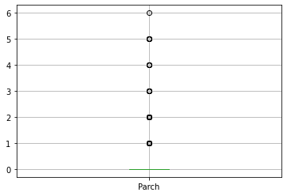

```python
eda.boxplot(column = ['Parch'])
```

```python
eda['Parch'].describe()
```

```
count    891.000000
mean       0.381594
std        0.806057
min        0.000000
25%        0.000000
50%        0.000000
75%        0.000000
max        6.000000
Name: Parch, dtype: float64
```

```python
IQR_parch= eda['Parch'].quantile(0.75)-eda['Parch'].quantile(0.25)
print(IQR_parch)
```

```
0.0
```

```python
Upper_OutlierLimit_parch = eda['Parch'].quantile(0.75) + 1.5*IQR_parch
Lower_OutlierLimit_parch = eda['Parch'].quantile(0.25) - 1.5*IQR_parch
print(Upper_OutlierLimit_parch)
print(Lower_OutlierLimit_parch)
```

```
0.0
0.0
```

```python
OutlierValues_parch = eda[(eda['Parch']>=Upper_OutlierLimit_parch) | (eda['Parch']<=Lower_OutlierLimit_parch)]
```

```python
for i in range(0,891):
    if eda['Age'][i] >= Upper_OutlierLimit_age:
        eda['Age'][i] = Upper_OutlierLimit_age
    elif eda['Age'][i] <= Lower_OutlierLimit_age:
        eda['Age'][i] = Lower_OutlierLimit_age
    else:
        continue
```

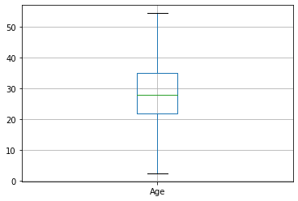

```python
eda.boxplot(column=['Age'])
```

```python
for i in range(0,891):
    if eda['Fare'][i] >= Upper_OutlierLimit_fare:
        eda['Fare'][i] = Upper_OutlierLimit_fare
    elif eda['Fare'][i] <= Lower_OutlierLimit_fare:
        eda['Fare'][i] = Lower_OutlierLimit_fare
    else:
        continue
```

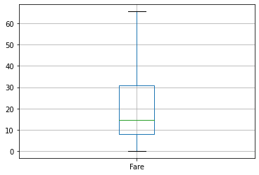

```python
eda.boxplot(column=['Fare'])
```

```python
for i in range(0,891):
    if eda['SibSp'][i] >= Upper_OutlierLimit_sibsp:
        eda['SibSp'][i] = Upper_OutlierLimit_sibsp
    elif eda['SibSp'][i] <= Lower_OutlierLimit_sibsp:
        eda['Sibsp'][i] = Lower_OutlierLimit_sibsp
    else:
        continue
```

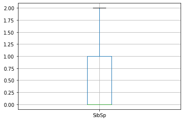

```python
eda.boxplot(column=['SibSp'])
```

```python
for i in range(0,891):
    if eda['Parch'][i] >= Upper_OutlierLimit_parch:
        eda['Parch'][i] = Upper_OutlierLimit_parch
    elif eda['Parch'][i] <= Lower_OutlierLimit_parch:
        eda['Parch'][i] = Lower_OutlierLimit_parch
    else:
        continue
```

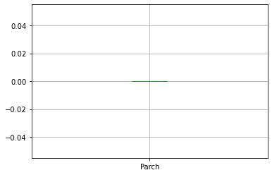

```python
eda.boxplot(column=['Parch'])
```

## Feature Engineering : Variable & Dummy Variable Creation

```python
obj = eda.dtypes == np.object
print(obj)
```

```
PassengerId    False
Survived       False
Pclass         False
Name            True
Sex             True
Age            False
SibSp          False
Parch          False
Ticket          True
Fare           False
Embarked        True
dtype: bool
```

```python
eda.columns[obj]
```

```
Index(['Name', 'Sex', 'Ticket', 'Embarked'], dtype='object')
```

Name and Ticket are descriptive data variables hence can be dropped.

```python
del eda['Name']
```

```python
del eda['Ticket']
```

```python
obj = eda.dtypes == np.object
print(obj)
```

```
PassengerId    False
Survived       False
Pclass         False
Sex             True
Age            False
SibSp          False
Parch          False
Fare           False
Embarked        True
dtype: bool
```

```python
eda.columns[obj]
```

```
Index(['Sex', 'Embarked'], dtype='object')
```

```python
dummydf = pd.DataFrame()

for i in eda.columns[obj]:
    dummy=pd.get_dummies(eda[i],drop_first=True)
    dummydf=pd.concat([dummydf, dummy], axis=1)

print(dummydf)
```

```
     male  Q  S
0       1  0  1
1       0  0  0
2       0  0  1
3       0  0  1
4       1  0  1
..    ... .. ..
886     1  0  1
887     0  0  1
888     0  0  1
889     1  0  0
890     1  1  0

[891 rows x 3 columns]
```

```python
eda1=pd.concat([eda,dummydf],axis=1)
eda1
```

|  | PassengerId | Survived | Pclass | Sex | Age | SibSp | Parch | Fare | Embarked | male | Q | S |
| --- | --- | --- | --- | --- | --- | --- | --- | --- | --- | --- | --- | --- |
| 0 | 1 | 0 | 3 | male | 22.0 | 1 | 0 | 7.2500 | S | 1 | 0 | 1 |
| 1 | 2 | 1 | 1 | female | 38.0 | 1 | 0 | 65.6344 | C | 0 | 0 | 0 |
| 2 | 3 | 1 | 3 | female | 26.0 | 0 | 0 | 7.9250 | S | 0 | 0 | 1 |
| 3 | 4 | 1 | 1 | female | 35.0 | 1 | 0 | 53.1000 | S | 0 | 0 | 1 |
| 4 | 5 | 0 | 3 | male | 35.0 | 0 | 0 | 8.0500 | S | 1 | 0 | 1 |
| ... | ... | ... | ... | ... | ... | ... | ... | ... | ... | ... | ... | ... |
| 886 | 887 | 0 | 2 | male | 27.0 | 0 | 0 | 13.0000 | S | 1 | 0 | 1 |
| 887 | 888 | 1 | 1 | female | 19.0 | 0 | 0 | 30.0000 | S | 0 | 0 | 1 |
| 888 | 889 | 0 | 3 | female | 28.0 | 1 | 0 | 23.4500 | S | 0 | 0 | 1 |
| 889 | 890 | 1 | 1 | male | 26.0 | 0 | 0 | 30.0000 | C | 1 | 0 | 0 |
| 890 | 891 | 0 | 3 | male | 32.0 | 0 | 0 | 7.7500 | Q | 1 | 1 | 0 |

891 rows × 12 columns

```python
eda1.drop(['Sex','Embarked'],axis=1,inplace=True)
```

```python
eda1
```

|  | PassengerId | Survived | Pclass | Age | SibSp | Parch | Fare | male | Q | S |
| --- | --- | --- | --- | --- | --- | --- | --- | --- | --- | --- |
| 0 | 1 | 0 | 3 | 22.0 | 1 | 0 | 7.2500 | 1 | 0 | 1 |
| 1 | 2 | 1 | 1 | 38.0 | 1 | 0 | 65.6344 | 0 | 0 | 0 |
| 2 | 3 | 1 | 3 | 26.0 | 0 | 0 | 7.9250 | 0 | 0 | 1 |
| 3 | 4 | 1 | 1 | 35.0 | 1 | 0 | 53.1000 | 0 | 0 | 1 |
| 4 | 5 | 0 | 3 | 35.0 | 0 | 0 | 8.0500 | 1 | 0 | 1 |
| ... | ... | ... | ... | ... | ... | ... | ... | ... | ... | ... |
| 886 | 887 | 0 | 2 | 27.0 | 0 | 0 | 13.0000 | 1 | 0 | 1 |
| 887 | 888 | 1 | 1 | 19.0 | 0 | 0 | 30.0000 | 0 | 0 | 1 |
| 888 | 889 | 0 | 3 | 28.0 | 1 | 0 | 23.4500 | 0 | 0 | 1 |
| 889 | 890 | 1 | 1 | 26.0 | 0 | 0 | 30.0000 | 1 | 0 | 0 |
| 890 | 891 | 0 | 3 | 32.0 | 0 | 0 | 7.7500 | 1 | 1 | 0 |

891 rows × 10 columns

# Conclusion

From this project we have accomplished the following:

1)Importing csv data into python

2)Classification of variables into:Continuous Data, Categorical Data, Discreet Data, Descriptive Data

3)Performing Univariate Analysis on all variables getting insights about them with the help of multiple plots

4)Performing Bivariate Analysis between all variables getting insights about the relations between them with the help of multiple plots

5)Detecting Null values in the Dataset:Dropping Cabin column with 77.10% Null values which would lead to error, Handling Null values of Age column by filling in median values

7)Creation of Dummy Variables for Object Variables to make data easier to handle by model

8)Dropping unnecessary columns which would not affect model calculations

-------------------x-----------------x----------------x---------------x---------------x----------------x----------------